# Effects of Inhibition on Trial Signals in 'numberStarred' Game

ID: 38 Game: numbersStarred Session: 37

### Inhibition in 'numberStarred'

- Let us now look into the output measures of the signal related to the specific game.
- In our case, we focus on 'numberStarred' and the effect of inhibition.

```python
"""
'Correct' is binary: 1 for a correct, 0 for incorrect answer
'Star' is binary: 1 when star present, 0 when star absent
'ET' is real: Event Time as recorded by the app
'RT': Reaction time as computed
'L1_trig': L1 norm of the triggering axis
'L1_rem': L1 norm of the remaining axis
'MD_trig': Maximal Deviation in opposite direction on the triggering axis
'MD_rem': Max Deviation of the remaining axis
'flip_trig': number of flips (turns) on the triggering axis
'flip_rem': number of flips on the remaining axis
'SE_trig': Sample Entropy of the triggering axis
'SE_rem': Sample Entropy on the remaining axis
"""

out_df = pandas.DataFrame({
                        'Correct':corrIncorr_label,
                        'Star':array_st_all,
                        'ET':time_event_all_values,
                        'RT':time_reaction_all_values,
                        'L1_trig':L1_trigger_all,
                        'L1_rem':L1_remaining_all,
                        'MD_trig':MD_trigger_all,
                        'MD_rem': MD_remaining_all,
                        'flip_trig':flips_trigger_all,
                        'flip_rem':flips_remaining_all,
                        'SE_trig':SE_y_all,
                        'SE_rem': SE_z_all
                        })
```

- We are looking into the data genegared by person ID = 38.
- The person has played 37 sessions of **numberStarred** game.

The number of trials played is given by:

```python
print('Number of trials played by ID = %g is %g.' %(ID,len(out_df)))
```

```
Number of trials played by ID = 38 is 1098.
```

Let us drop NaN values and take a look into the generated dataframe.

```python
out_df = out_df.dropna()
print('Number of trials after removing missing values is %g.' %len(out_df))
out_df.head()
```

```
Number of trials after removing missing values is 1098.
```

|  | Correct | Star | ET | RT | L1_trig | L1_rem | MD_trig | MD_rem | flip_trig | flip_rem | SE_trig | SE_rem |
| --- | --- | --- | --- | --- | --- | --- | --- | --- | --- | --- | --- | --- |
| 0 | 1 | 0 | 1.91274 | 1.379466 | 0.401345 | 0.007522 | 0.002319 | 0.029438 | 1.0 | 2.0 | 0.020834 | 0.024382 |
| 1 | 1 | 0 | 1.80024 | 1.539375 | 0.383120 | 0.013041 | 0.062588 | 0.018813 | 3.0 | 6.0 | 0.020834 | 0.023371 |
| 2 | 1 | 0 | 1.21662 | 0.869690 | 0.551969 | 0.009854 | 0.151736 | 0.015861 | 2.0 | 4.0 | 0.020834 | 0.028523 |
| 3 | 0 | 1 | 1.93337 | 1.719315 | 0.512425 | 0.175728 | 0.021988 | 0.505568 | 3.0 | 3.0 | 0.020834 | 0.022857 |
| 4 | 1 | 1 | 1.56119 | 1.289464 | 0.639767 | 0.093573 | 0.475433 | 0.143712 | 3.0 | 4.0 | 0.022833 | 0.020834 |

We will make two dataframes - one corresponding to the trials with star and one to the trials without star present on the screen.

```python
# set with Star(s)
out_Star = out_df[(out_df.Correct == 1) & (out_df.Star == 1)]
# set withot Star(s)
out_noStar = out_df[(out_df.Correct == 1) & (out_df.Star == 0)]
```

Let us remove now superfluous columns 'Correct' and 'Star'.

**Note.** *This means that we restrict our analysis only to the case when **answers are correct**.*

```python
out_Star = out_Star.drop(['Correct','Star'], axis = 1)
out_noStar = out_noStar.drop(['Correct','Star'], axis = 1)
out_Star.head()
```

|  | ET | RT | L1_trig | L1_rem | MD_trig | MD_rem | flip_trig | flip_rem | SE_trig | SE_rem |
| --- | --- | --- | --- | --- | --- | --- | --- | --- | --- | --- |
| 4 | 1.56119 | 1.289464 | 0.639767 | 0.093573 | 0.475433 | 0.143712 | 3.0 | 4.0 | 0.022833 | 0.020834 |
| 8 | 4.66648 | 4.258410 | 0.538255 | 0.015579 | 0.472238 | 0.072598 | 3.0 | 3.0 | 0.022185 | 0.020834 |
| 10 | 2.69677 | 2.349098 | 0.539925 | 0.071385 | 0.495058 | 0.111622 | 5.0 | 2.0 | 0.020834 | 0.070581 |
| 11 | 2.03043 | 1.509407 | 0.549904 | 0.034633 | 0.445146 | 0.090589 | 4.0 | 12.0 | 0.026283 | 0.024098 |
| 12 | 4.18215 | 3.778574 | 0.489068 | 0.040705 | 0.496461 | 0.101787 | 3.0 | 1.0 | 0.020834 | 0.033715 |

## Finding a statistical significance

Let us examin the behaviour of L1 norms on the leading (triggering) and remaining axis.

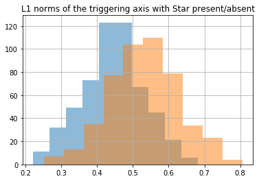

```python
plt.title('L1 norms of the triggering axis with Star present/absent')
out_noStar.L1_trig.hist(alpha=0.5)
out_Star.L1_trig.hist(alpha=0.5)
plt.show()
```

Upon visual inspection, the histograms look like they could be generated by a normal distribution. This is a good news since this allows us to use standard tests like t-test. But to make sure that this is the case beyond visual inspection, we shall condact a normal test.

```python
def normalityTest(x):
    from scipy import stats
    k, p = stats.normaltest(x)
    alpha = 1e-3
    print("p = {:g}".format(p))
    if p < alpha:  # null hypothesis: out_Star.L1_trig comes from a normal distribution
        print("The null hypothesis can be rejected")
    else:
        print("The null hypothesis cannot be rejected")
```

```python
normalityTest(out_noStar.L1_trig)
normalityTest(out_Star.L1_trig)
```

```
p = 0.651486
The null hypothesis cannot be rejected
p = 0.973625
The null hypothesis cannot be rejected
```

### T-test Statistics

The Student’s t-Test is a statistical hypothesis test for testing whether two samples are expected to have been drawn from the same population.

The p-value is compared to a chosen significance level (alpha) such as 0.05 or in our case 0.001 to determine if the null hypothesis can be rejected:

- If $p >$ alpha: Accept null hypothesis that the means are equal.
- If $p <=$ alpha: Reject null hypothesis that the means are equal.

We shall use scipy.stats to calculate the T-test for the means of two independent samples of scores.

```python
from scipy.stats import ttest_ind, ttest_ind_from_stats
from scipy.special import stdtr

a = out_noStar.L1_trig
b = out_Star.L1_trig
# Use scipy.stats.ttest_ind.
t, p = ttest_ind(a, b, equal_var=False)
print("ttest_ind:       t = %g  p = %g" % (t, p))
```

```
ttest_ind:       t = -14.933  p = 1.41804e-45
```

Now, let us look how $L_1$-norms along the remaining axis behaves. Notice that we will have to make a log transformation because the non-Gaussian properties of the $L_1$-norms along the nonleading axis.

```python
t, p = ttest_ind(numpy.log(out_noStar.L1_rem), numpy.log(out_Star.L1_rem), equal_var=False)
print("ttest_ind:       t = %g  p = %g" % (t, p))
```

```
ttest_ind:       t = -1.81812  p = 0.0693348
```

We do not observe a statistical significance. **Question:** Why?

**Answer:** Because the nonleading axis is not relevant to pure inhibition.

### Calculate Difference Effect Size

The difference between groups is often referred to as the “d family” of effect size methods.

This name comes from perhaps the most common method for calculating the difference between the mean value of groups, called Cohen’s d.

Cohen’s d measures the difference between the mean from two Gaussian-distributed variables. It is a standard score that summarizes the difference in terms of the number of standard deviations. Because the score is standardized, there is a table for the interpretation of the result, summarized as:

- Small Effect Size: d=0.20
- Medium Effect Size: d=0.50
- Large Effect Size: d=0.80
- The Cohen’s d calculation is not provided in Python; we can calculate it manually.
- The function below will calculate the Cohen’s d measure for two samples of real-valued variables.

```python
from numpy.random import seed
from numpy import mean
from numpy import var
from math import sqrt

def cohend(d1, d2):
    # calculate the size of samples
    n1, n2 = len(d1), len(d2)
    # calculate the variance of the samples
    s1, s2 = var(d1, ddof=1), var(d2, ddof=1)
    # calculate the pooled standard deviation
    s = sqrt(((n1 - 1) * s1 + (n2 - 1) * s2) / (n1 + n2 - 2))
    # calculate the means of the samples
    u1, u2 = mean(d1), mean(d2)
    # calculate the effect size
    return (u1 - u2) / s
```

Let us define a custom function *ttest*, which will compute t, p, and Cohen-d.

```python
def ttest(a,b):
    t, p = ttest_ind(b, a, equal_var=False)
    print("ttest_ind:      t = %g  p = %g   Cohen-d = %g" % (t, p, cohend(b,a)))

ttest(out_noStar.L1_trig,out_Star.L1_trig)
```

```
ttest_ind:      t = 14.933  p = 1.41804e-45   Cohen-d = 0.936421
```

Notice a wanishing p-value ( $\ll 0.001$ ) and a large effect size ( $0.94 > 0.8$ ).

## Looking into the Remaining Variables

- Let us look into Event Time.
- We observe only a weak effect (i.e., the detailed sensor data contain usful information)

```python
ttest(out_noStar.ET,out_Star.ET)
```

```
ttest_ind:      t = 5.00656  p = 6.62822e-07   Cohen-d = 0.315858
```

### Maximal Deviation, Turns, and SE

```python
# MD_trig
ttest(out_noStar.MD_trig,out_Star.MD_trig)
# MD_rem
ttest(out_noStar.MD_rem,out_Star.MD_rem)
# flip_trig
ttest(out_noStar.flip_trig,out_Star.flip_trig)
# flip_trig
ttest(out_noStar.flip_rem,out_Star.flip_rem)
# SampleEntropy_trig
ttest(out_noStar.SE_trig,out_Star.SE_trig)
# SampleEntropy_rem
ttest(out_noStar.SE_rem,out_Star.SE_rem)
```

```
ttest_ind:      t = 107.842  p = 0   Cohen-d = 6.37573
ttest_ind:      t = -0.172357  p = 0.863191   Cohen-d = -0.0106349
ttest_ind:      t = 2.43822  p = 0.0149285   Cohen-d = 0.151461
ttest_ind:      t = 3.50638  p = 0.000474285   Cohen-d = 0.218847
ttest_ind:      t = -3.27666  p = 0.00108736   Cohen-d = -0.199558
ttest_ind:      t = -1.38832  p = 0.165344   Cohen-d = -0.0865236
```

### Brief Comment on Significance

- We observe a strong effect in Maximal Deviation
- Surprisingly, we do not observe an effect in Sample Entropy

## Spearman Correlation of the Outcome Measures

As a first step, we ran nonparametric correlation analyses to evaluate the eventual degree of similarity between the entropy measures and the geometric measures.

Let us look into Sperman's correlations for all possible distinct pairs of measure.

```python
df_normalized = out_df[(out_df.Correct == 1)].drop(['Correct','Star'], axis = 1)
corr = df_normalized.corr(method='spearman')
corr.style.background_gradient(cmap='coolwarm')
```

|  | ET | RT | L1_trig | L1_rem | MD_trig | MD_rem | flip_trig | flip_rem | SE_trig | SE_rem |
| --- | --- | --- | --- | --- | --- | --- | --- | --- | --- | --- |
| ET | 1 | 0.955773 | 0.200234 | 0.0671445 | 0.202155 | 0.0811418 | 0.424305 | 0.242793 | 0.0630203 | 0.0153612 |
| RT | 0.955773 | 1 | 0.196653 | 0.0765298 | 0.205641 | 0.0869088 | 0.434254 | 0.251632 | -0.0306486 | -0.00433415 |
| L1_trig | 0.200234 | 0.196653 | 1 | 0.0456425 | 0.451914 | 0.0337344 | 0.0901128 | 0.0377824 | -0.00778711 | -0.100265 |
| L1_rem | 0.0671445 | 0.0765298 | 0.0456425 | 1 | 0.0503862 | 0.872644 | 0.0769889 | -0.0810467 | 0.177394 | 0.0184745 |
| MD_trig | 0.202155 | 0.205641 | 0.451914 | 0.0503862 | 1 | 0.0083795 | 0.0580303 | 0.110068 | -0.115663 | 0.0384432 |
| MD_rem | 0.0811418 | 0.0869088 | 0.0337344 | 0.872644 | 0.0083795 | 1 | 0.105885 | -0.121862 | 0.245793 | 0.0684341 |
| flip_trig | 0.424305 | 0.434254 | 0.0901128 | 0.0769889 | 0.0580303 | 0.105885 | 1 | 0.0927902 | -0.00272975 | 0.0225703 |
| flip_rem | 0.242793 | 0.251632 | 0.0377824 | -0.0810467 | 0.110068 | -0.121862 | 0.0927902 | 1 | -0.037116 | -0.069888 |
| SE_trig | 0.0630203 | -0.0306486 | -0.00778711 | 0.177394 | -0.115663 | 0.245793 | -0.00272975 | -0.037116 | 1 | -0.506686 |
| SE_rem | 0.0153612 | -0.00433415 | -0.100265 | 0.0184745 | 0.0384432 | 0.0684341 | 0.0225703 | -0.069888 | -0.506686 | 1 |

Should we have defined $L_1$-norm as $L_1^{\mathrm{new}} = T \cdot L_1$, then 'ET' and 'L1_trig' would be highly correlated. This is expected.

```python
print('New correlation between L1_trig and ET is %g.' %numpy.corrcoef(out_Star.L1_trig*out_Star.ET, out_Star.ET)[0, 1])
```

```
New correlation between L1_trig and ET is 0.915592.
```

Take a look into Spearman's correlation with unnormalized $L_1$-norms.

```python
df_nonnormalized = out_df[(out_df.Correct == 1)].drop(['Correct','Star'], axis = 1)
df_nonnormalized.L1_trig = df_nonnormalized.L1_trig * df_nonnormalized.ET
df_nonnormalized.L1_rem = df_nonnormalized.L1_rem * df_nonnormalized.ET

corr = df_nonnormalized.corr(method='spearman')
corr.style.background_gradient(cmap='coolwarm')
```

|  | ET | RT | L1_trig | L1_rem | MD_trig | MD_rem | flip_trig | flip_rem | SE_trig | SE_rem |
| --- | --- | --- | --- | --- | --- | --- | --- | --- | --- | --- |
| ET | 1 | 0.955773 | 0.854513 | 0.413862 | 0.202155 | 0.0811418 | 0.424305 | 0.242793 | 0.0630203 | 0.0153612 |
| RT | 0.955773 | 1 | 0.822189 | 0.409709 | 0.205641 | 0.0869088 | 0.434254 | 0.251632 | -0.0306486 | -0.00433415 |
| L1_trig | 0.854513 | 0.822189 | 1 | 0.363505 | 0.364762 | 0.0639755 | 0.361421 | 0.193241 | 0.0349794 | -0.0407499 |
| L1_rem | 0.413862 | 0.409709 | 0.363505 | 1 | 0.122155 | 0.805502 | 0.229424 | 0.0191482 | 0.174801 | 0.025343 |
| MD_trig | 0.202155 | 0.205641 | 0.364762 | 0.122155 | 1 | 0.0083795 | 0.0580303 | 0.110068 | -0.115663 | 0.0384432 |
| MD_rem | 0.0811418 | 0.0869088 | 0.0639755 | 0.805502 | 0.0083795 | 1 | 0.105885 | -0.121862 | 0.245793 | 0.0684341 |
| flip_trig | 0.424305 | 0.434254 | 0.361421 | 0.229424 | 0.0580303 | 0.105885 | 1 | 0.0927902 | -0.00272975 | 0.0225703 |
| flip_rem | 0.242793 | 0.251632 | 0.193241 | 0.0191482 | 0.110068 | -0.121862 | 0.0927902 | 1 | -0.037116 | -0.069888 |
| SE_trig | 0.0630203 | -0.0306486 | 0.0349794 | 0.174801 | -0.115663 | 0.245793 | -0.00272975 | -0.037116 | 1 | -0.506686 |
| SE_rem | 0.0153612 | -0.00433415 | -0.0407499 | 0.025343 | 0.0384432 | 0.0684341 | 0.0225703 | -0.069888 | -0.506686 | 1 |

## Observations

- A strong positive correlation between *Event Time* and *Reaction Time* (this is expected)
- A strong correlation between *L1_trig* and *ET* (this is by construction of $L_1$-norm)
- A significan correlation between *Maximal Deviation of the nontriggering axis* (MD_rem) and L1_rem (the greater the amplitude of the nonleading (nontriggering) deviation (in the opposite direction from the target) the greater L1_rem norm)
- No significant correlation between geometric and entropic (Sample Entropy) meassures (this might be due to not particularily well tuned parameters)